# National patterns of alpha-gal sensitisation in Australia

Laboratory surveillance of alpha-gal-specific IgE testing, 2014-2024

# Disclaimer

**Preprint Research Notice:** The findings and analyses displayed herein are part of ongoing research and are provisional. They may be *incomplete, subject to revision, or contain errors*.

# Home

## Abstract

**Objectives:** To characterise national patterns of alpha-gal (α‑Gal) specific immunoglobulin E (sIgE) sensitisation in Australia, including temporal trends in testing and detection, geographic distribution, demographic correlates of test positivity, and longitudinal antibody dynamics.

**Design:** Retrospective analysis of α‑Gal sIgE ImmunoCAP™ test results from 1 January 2014 to 31 December 2024.

**Setting, Participants:** Deidentified laboratory records from 14,075 individuals tested across Australia, with residential postcodes mapped to Statistical Areas Level 3 (SA3).

**Main outcome measures:** Test volumes, α-Gal sensitisation (positive test) counts, positivity rates, spatial clustering metrics, demographic correlates of test positivity, and longitudinal α‑Gal sIgE trajectories.

**Results:** Overall, 35.7% (5,025) of individuals tested positive (≥0.1 kU/L α‑Gal sIgE). Testing volume increased 330% over the study period, with detections accelerating from around 2022. Decomposition attributed 79% of case growth to expanded testing, with up to 21%unexplained by measurable surveillance changes. Sensitised individuals clustered along the eastern seaboard within the range of Ixodes holocyclus, with extreme spatial clustering: three SA3 regions accounted for over one-quarter of nationally detected sensitisation. Females comprised the majority of sensitised individuals, although males had higher positivity. Positivity increased with age, peaking at 45-74 years. Among 1,017 repeatedly tested individuals, α‑Gal sIgE levels antibodies declined in 73.7% of people by a median of 20.4% annually.

**Conclusions:** This first national assessment of α‑Gal sIgE sensitisation in Australia reveals a substantial, geographically concentrated, and growing burden. The spatial concentration suggests targeted public health interventions could efficiently reach most highest-risk people. Testing expansion is the dominant driver of rising case numbers, but a residual increase remains that surveillance expansion alone does not explain. Laboratory data cannot separate this from rising clinician and public awareness, and prospective studies are needed to confirm genuine disease emergence.

## About This Interactive Application

Users can explore:

- Interactive versions of every manuscript figure, panel by panel, with zoom, pan and hover detail
- **Figure S7** is the one exception, shown as published: each panel pairs a national map with an east-coast inset, and Figure 3 above is the zoomable equivalent
- **Data tables and detailed regional statistics**

Navigate through the sections below to explore different aspects of the analysis. All figures are interactive and can be zoomed and panned for detailed examination.

## Data Sources

Deidentified data were obtained from all [a-Gal sIgE immunoCAP™](https://www.allergy.org.au/patients/food-allergy/mammalian-meat-tick-faq?highlight=WyJ0byJd) tests submitted to the following pathology service providers between January 1 2014, and December 31 2024:

- [QML Pathology](https://www.qml.com.au/)
- [Sullivan Nicolaides Pathology](https://www.snp.com.au/)
- [Douglas Hanley Moir Pathology](https://www.dhm.com.au/)
- [Laverty Pathology](https://www.laverty.com.au/)

Patients’ residential locations were aggregated to Australian Bureau of Statistics (ABS) statistical areas level 3 (SA3) define by the [Australian Statistical Geography Standard Edition 3](https://www.abs.gov.au/statistics/standards/australian-statistical-geography-standard-asgs-edition-3/latest-release), which is designed to create meaningful functional areas of regional towns and cities with populations between 30,000 and 130,000.

Adjusted number of sensitised individuals are displayed as cases per 1M population per year (1M PPY) which adjusts for both regional population size and samples time from (2014-2024) using annual regional population estimates from the [ABS](https://www.abs.gov.au/statistics/people/population/national-state-and-territory-population/latest-release) as population denominators.

```
Sensitised individuals per 1M PPY = (cumulative_incidence_2014-2024 / cumulative_annual_population_2014-2024) * 1000000
```

© 2025 | For questions or feedback, please contact: alexander.gofton@csiro.au

# Figure 1. Annual trends in α-Gal sIgE testing and its decomposition, 2014-2024

**A. Total tests**

[interactive chart not shown]

**Figure 1** Annual trends in α-Gal sIgE testing and its decomposition, 2014-2024. **(A)** Total tests performed. **(B)** Number of SA3 regions from which α-Gal sIgE test was performed. **(C)** Sources of the increase in testing volume relative to 2014, decomposed across SA3 regions into tests performed in regions new since 2014, the net change within regions testing in both years, and tests lost from regions that ceased testing. Circles mark the observed net change. **(D)** The percentage change in testing intensity within SA3 regions; points show individual SA3 regions, violin plot shows probability density, boxplot indicates median (63.0%) and interquartile range. Red dashed lines and ribbons indicate linear regression and standard errors, respectively. sIgE: specific immunoglobulin E.

**B. Testing regions**

[interactive chart not shown]

**Figure 1** Annual trends in α-Gal sIgE testing and its decomposition, 2014-2024. **(A)** Total tests performed. **(B)** Number of SA3 regions from which α-Gal sIgE test was performed. **(C)** Sources of the increase in testing volume relative to 2014, decomposed across SA3 regions into tests performed in regions new since 2014, the net change within regions testing in both years, and tests lost from regions that ceased testing. Circles mark the observed net change. **(D)** The percentage change in testing intensity within SA3 regions; points show individual SA3 regions, violin plot shows probability density, boxplot indicates median (63.0%) and interquartile range. Red dashed lines and ribbons indicate linear regression and standard errors, respectively. sIgE: specific immunoglobulin E.

**C. Sources of testing growth**

[interactive chart not shown]

**Figure 1** Annual trends in α-Gal sIgE testing and its decomposition, 2014-2024. **(A)** Total tests performed. **(B)** Number of SA3 regions from which α-Gal sIgE test was performed. **(C)** Sources of the increase in testing volume relative to 2014, decomposed across SA3 regions into tests performed in regions new since 2014, the net change within regions testing in both years, and tests lost from regions that ceased testing. Circles mark the observed net change. **(D)** The percentage change in testing intensity within SA3 regions; points show individual SA3 regions, violin plot shows probability density, boxplot indicates median (63.0%) and interquartile range. Red dashed lines and ribbons indicate linear regression and standard errors, respectively. sIgE: specific immunoglobulin E.

**D. Within-region testing intensity**

[interactive chart not shown]

**Figure 1** Annual trends in α-Gal sIgE testing and its decomposition, 2014-2024. **(A)** Total tests performed. **(B)** Number of SA3 regions from which α-Gal sIgE test was performed. **(C)** Sources of the increase in testing volume relative to 2014, decomposed across SA3 regions into tests performed in regions new since 2014, the net change within regions testing in both years, and tests lost from regions that ceased testing. Circles mark the observed net change. **(D)** The percentage change in testing intensity within SA3 regions; points show individual SA3 regions, violin plot shows probability density, boxplot indicates median (63.0%) and interquartile range. Red dashed lines and ribbons indicate linear regression and standard errors, respectively. sIgE: specific immunoglobulin E.

# Figure 2. Annual α-Gal sensitisation detections and test positivity, 2014-2024

**A. Sensitised individuals detected**

[interactive chart not shown]

**Figure 2** Annual α-Gal sensitisation detections and test positivity, 2014-2024. **(A)** Number of α-Gal sensitised individuals detected annually with segmented linear regression model fit. **(B)** Annual positivity rate with linear regression model fit, excluding outlier year 2014. **(C)** Decomposition of the growth in detected α-Gal sensitisation relative to the pooled 2018-2020 reference period. Segmented and linear regression models and standard errors indicated by red dashed lines and ribbons, respectively. Dotted line and light blue shading indicates the segmented linear regression breakpoint with 95% confidence intervals. sIgE: specific immunoglobulin E.

**B. Positivity rate**

[interactive chart not shown]

**Figure 2** Annual α-Gal sensitisation detections and test positivity, 2014-2024. **(A)** Number of α-Gal sensitised individuals detected annually with segmented linear regression model fit. **(B)** Annual positivity rate with linear regression model fit, excluding outlier year 2014. **(C)** Decomposition of the growth in detected α-Gal sensitisation relative to the pooled 2018-2020 reference period. Segmented and linear regression models and standard errors indicated by red dashed lines and ribbons, respectively. Dotted line and light blue shading indicates the segmented linear regression breakpoint with 95% confidence intervals. sIgE: specific immunoglobulin E.

**C. Sources of detection growth**

[interactive chart not shown]

**Figure 2** Annual α-Gal sensitisation detections and test positivity, 2014-2024. **(A)** Number of α-Gal sensitised individuals detected annually with segmented linear regression model fit. **(B)** Annual positivity rate with linear regression model fit, excluding outlier year 2014. **(C)** Decomposition of the growth in detected α-Gal sensitisation relative to the pooled 2018-2020 reference period. Segmented and linear regression models and standard errors indicated by red dashed lines and ribbons, respectively. Dotted line and light blue shading indicates the segmented linear regression breakpoint with 95% confidence intervals. sIgE: specific immunoglobulin E.

# Figure 3. Geographic distribution of α-Gal sensitisation

[interactive chart not shown]

**Figure 3** Geographic distribution of laboratory-detected α-Gal sIgE-positive individuals (by residential SA3) per 1M PPY in Australia, 2014-2024

## Data Table

| SA3 Region | α-Gal sensitised individuals (2014-2024) | α-Gal sensitised individuals per 1M PPY |
| --- | --- | --- |
| Pittwater | 492 | 704.0056778344099 |
| Gold Coast Hinterland | 96 | 440.0137504297009 |
| Coffs Harbour | 431 | 431.3809093429498 |
| Sunshine Coast Hinterland | 251 | 402.7521934750936 |
| Richmond Valley - Hinterland | 303 | 384.0917561 |
| Richmond Valley - Coastal | 258 | 275.3221696240679 |
| Warringah | 455 | 261.606412864366 |
| Ku-ring-gai | 290 | 211.0499955606725 |
| Canberra East | 4 | 206.6115702479339 |
| South Coast | 163 | 198.7206292738651 |

[output cut: 349 more lines]

# Figure 4. Geographic concentration of α-Gal sensitisation

**A. Lorenz curve**

[interactive chart not shown]

**Figure 4** Geographic concentration of α‑Gal sensitisation across Australian SA3 regions. **(A)** Lorenz curve showing cumulative distribution of sensitisation across SA3 regions (ranked by case burden). The diagonal dashed line represents perfect equality; deviation from this line indicates concentration. **(B)** Pareto chart showing the proportion of total sensitisation accounted for by cumulative percentages of SA3 regions. PPY: population per year.

**B. Pareto chart**

[interactive chart not shown]

**Figure 4** Geographic concentration of α‑Gal sensitisation across Australian SA3 regions. **(A)** Lorenz curve showing cumulative distribution of sensitisation across SA3 regions (ranked by case burden). The diagonal dashed line represents perfect equality; deviation from this line indicates concentration. **(B)** Pareto chart showing the proportion of total sensitisation accounted for by cumulative percentages of SA3 regions. PPY: population per year.

# Figure 5. Longitudinal changes in α-Gal sIgE levels

**A. Annual rate of change**

[interactive chart not shown]

**Figure 5** Longitudinal changes in α-Gal sIgE levels in individuals with ≥2 tests (n=1,017). **(A)** Distribution of individual annual rates of change (β) in log10 α-Gal sIgE/year percentage change from previous test, estimated from linear mixed-effects models. Dashed line indicates the median rate of change. **(B)** Comparison of first and last α-Gal sIgE measurements for each individual. The red dashed lines and shaded area show the linear regression and standard error, respectively. α-Gal sIgE levels reported at actual values below the 0.1 kU/L positivity cut-off were retained as real values and those reported as “<0.1 kU/L” were assigned 0.1 kU/L but flagged as negative test results; 17 undetectable results were retained at zero and 13 results reported as “>100 kU/L” were assigned 100 kU/L. sIgE: specific immunoglobulin E.

**B. First vs last test**

[interactive chart not shown]

**Figure 5** Longitudinal changes in α-Gal sIgE levels in individuals with ≥2 tests (n=1,017). **(A)** Distribution of individual annual rates of change (β) in log10 α-Gal sIgE/year percentage change from previous test, estimated from linear mixed-effects models. Dashed line indicates the median rate of change. **(B)** Comparison of first and last α-Gal sIgE measurements for each individual. The red dashed lines and shaded area show the linear regression and standard error, respectively. α-Gal sIgE levels reported at actual values below the 0.1 kU/L positivity cut-off were retained as real values and those reported as “<0.1 kU/L” were assigned 0.1 kU/L but flagged as negative test results; 17 undetectable results were retained at zero and 13 results reported as “>100 kU/L” were assigned 100 kU/L. sIgE: specific immunoglobulin E.

# Figure S1. Distribution of α-Gal sIgE results

[interactive chart not shown]

**Figure S1** Histogram of the distribution of α‑Gal sIgE tests results across the whole tested cohort. Red dotted line shows the 0.1 kU/L positivity threshold. sIgE: specific immunoglobulin E.

# Figure S2. Age distribution by sex

**A. All tested**

[interactive chart not shown]

**Figure S2** Age distribution by sex of all tested people **(A)** and people positive (0.1 kU/L) α‑Gal sIgE tests.

**B. α-Gal sIgE positive**

[interactive chart not shown]

**Figure S2** Age distribution by sex of all tested people **(A)** and people positive (0.1 kU/L) α‑Gal sIgE tests.

# Figure S3. Positivity ratios by age and sex

**A. Male vs female**

[interactive chart not shown]

**Figure S3** Positivity ratios comparing: **(A)** males to females within each age category, **(B)** each age group to the reference (25–34 years, pooled sexes), and **(C)** all age-sex combinations to females aged 25–34 years (the lowest-positivity group, 18.5% positivity). Positivity ratios represent the ratio of test positivity between strata among tested individuals and do not indicate population-level risk. Filled circles indicate statistical significance (p < 0.01); open circles indicate non-significant comparisons. Error bars represent 95% confidence intervals. Dashed vertical line indicates a positivity ratio of 1.0 (no difference from reference group).

**B. Age vs 25-34 reference**

[interactive chart not shown]

**Figure S3** Positivity ratios comparing: **(A)** males to females within each age category, **(B)** each age group to the reference (25–34 years, pooled sexes), and **(C)** all age-sex combinations to females aged 25–34 years (the lowest-positivity group, 18.5% positivity). Positivity ratios represent the ratio of test positivity between strata among tested individuals and do not indicate population-level risk. Filled circles indicate statistical significance (p < 0.01); open circles indicate non-significant comparisons. Error bars represent 95% confidence intervals. Dashed vertical line indicates a positivity ratio of 1.0 (no difference from reference group).

**C. Age-sex vs female 25-34**

[interactive chart not shown]

**Figure S3** Positivity ratios comparing: **(A)** males to females within each age category, **(B)** each age group to the reference (25–34 years, pooled sexes), and **(C)** all age-sex combinations to females aged 25–34 years (the lowest-positivity group, 18.5% positivity). Positivity ratios represent the ratio of test positivity between strata among tested individuals and do not indicate population-level risk. Filled circles indicate statistical significance (p < 0.01); open circles indicate non-significant comparisons. Error bars represent 95% confidence intervals. Dashed vertical line indicates a positivity ratio of 1.0 (no difference from reference group).

# Figure S4. Sensitivity of the testing-volume split to the attribution rule

[interactive chart not shown]

**Figure S4** Share of observed 2014–2024 growth in α-gal sIgE testing volume attributed to geographic expansion and to testing intensity, under six decompositions of the identity T=N×I. The attributed geographic share ranges from 26% to 56% depending only on how the cross-product is handled.

# Figure S5. Patient-to-clinician distance

[interactive chart not shown]

**Figure S5** Geographic distance between patient residential and referring clinicians practice SA2 region showing how far patients travel for their consultation for 6,404 tests in which both variables were obtained.

# Figure S6. Geographic concentration standardised by testing volume

**A. Lorenz curves vs population**

[interactive chart not shown]

**Figure S6** Geographic concentration of α-Gal sensitisation standardised by testing volume, Australian SA3 regions, 2014–2024. **(A)** Lorenz curves for sensitised individuals and persons tested, with population as denominator, regions ranked from highest to lowest rate; the dashed diagonal is the line of equality. The curve for sensitisation lies outside that for testing, indicating greater concentration. **(B)** Lorenz curve for sensitised individuals with persons tested as denominator, regions ranked by positivity, removing population from the comparison (Gini coefficient = 0.30). **(C)** Standardised positivity ratios with Poisson 95% confidence intervals for the 30 regions with the highest population-adjusted burden, ordered by ratio; the dashed line marks parity with national positivity and point size is proportional to persons tested. **(D)** Sensitised individuals per 1M PPY against persons tested per 1M PPY, logarithmic axes, point size proportional to persons tested; the dashed line is the expectation under constant national positivity (35.6%), and the 30 regions with the highest population-adjusted burden are highlighted. PPY: population per year.

**B. Lorenz curve vs testing volume**

[interactive chart not shown]

**Figure S6** Geographic concentration of α-Gal sensitisation standardised by testing volume, Australian SA3 regions, 2014–2024. **(A)** Lorenz curves for sensitised individuals and persons tested, with population as denominator, regions ranked from highest to lowest rate; the dashed diagonal is the line of equality. The curve for sensitisation lies outside that for testing, indicating greater concentration. **(B)** Lorenz curve for sensitised individuals with persons tested as denominator, regions ranked by positivity, removing population from the comparison (Gini coefficient = 0.30). **(C)** Standardised positivity ratios with Poisson 95% confidence intervals for the 30 regions with the highest population-adjusted burden, ordered by ratio; the dashed line marks parity with national positivity and point size is proportional to persons tested. **(D)** Sensitised individuals per 1M PPY against persons tested per 1M PPY, logarithmic axes, point size proportional to persons tested; the dashed line is the expectation under constant national positivity (35.6%), and the 30 regions with the highest population-adjusted burden are highlighted. PPY: population per year.

**C. Standardised positivity ratios**

[interactive chart not shown]

**Figure S6** Geographic concentration of α-Gal sensitisation standardised by testing volume, Australian SA3 regions, 2014–2024. **(A)** Lorenz curves for sensitised individuals and persons tested, with population as denominator, regions ranked from highest to lowest rate; the dashed diagonal is the line of equality. The curve for sensitisation lies outside that for testing, indicating greater concentration. **(B)** Lorenz curve for sensitised individuals with persons tested as denominator, regions ranked by positivity, removing population from the comparison (Gini coefficient = 0.30). **(C)** Standardised positivity ratios with Poisson 95% confidence intervals for the 30 regions with the highest population-adjusted burden, ordered by ratio; the dashed line marks parity with national positivity and point size is proportional to persons tested. **(D)** Sensitised individuals per 1M PPY against persons tested per 1M PPY, logarithmic axes, point size proportional to persons tested; the dashed line is the expectation under constant national positivity (35.6%), and the 30 regions with the highest population-adjusted burden are highlighted. PPY: population per year.

**D. Sensitisation vs testing rate**

[interactive chart not shown]

**Figure S6** Geographic concentration of α-Gal sensitisation standardised by testing volume, Australian SA3 regions, 2014–2024. **(A)** Lorenz curves for sensitised individuals and persons tested, with population as denominator, regions ranked from highest to lowest rate; the dashed diagonal is the line of equality. The curve for sensitisation lies outside that for testing, indicating greater concentration. **(B)** Lorenz curve for sensitised individuals with persons tested as denominator, regions ranked by positivity, removing population from the comparison (Gini coefficient = 0.30). **(C)** Standardised positivity ratios with Poisson 95% confidence intervals for the 30 regions with the highest population-adjusted burden, ordered by ratio; the dashed line marks parity with national positivity and point size is proportional to persons tested. **(D)** Sensitised individuals per 1M PPY against persons tested per 1M PPY, logarithmic axes, point size proportional to persons tested; the dashed line is the expectation under constant national positivity (35.6%), and the 30 regions with the highest population-adjusted burden are highlighted. PPY: population per year.

# Figure S7. Population- and testing-standardised burden

Each panel is the published static pair: all of mainland Australia on the left, south-east Queensland and eastern New South Wales on the right. Figure 3 above is the zoomable equivalent of panel A.

**A. Sensitisation rate**

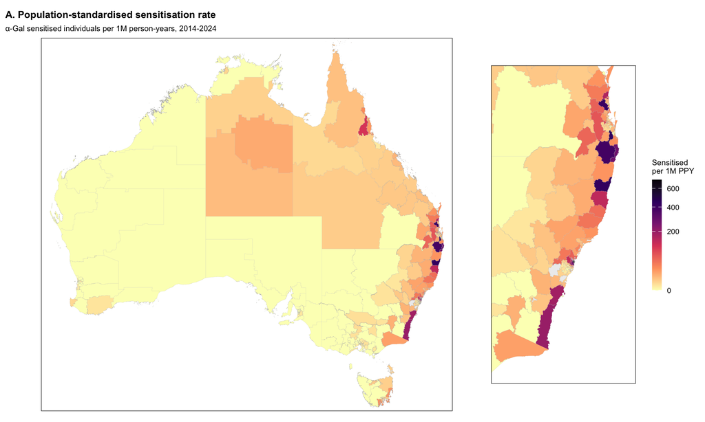

**Figure S7** Population-standardised and testing-standardised burden of α-Gal sensitisation, Australian SA3 regions, 2014–2024. Each panel shows all of mainland Australia (left) and zoomed in south-east Queensland and eastern New South Wales (right). **(A)** Sensitised individuals per million person-years, the population-standardised rate reported in the main text. **(B)** Persons tested per million person-years, showing testing intensity. **(C)** Test positivity (empirical Bayes smoothed) for regions with at least 20 persons tested, in which testing volume is the denominator; national positivity is 35.6% and regions with insufficient testing are shown in grey. Colour scales in A and B are square-root transformed.

**B. Testing intensity**

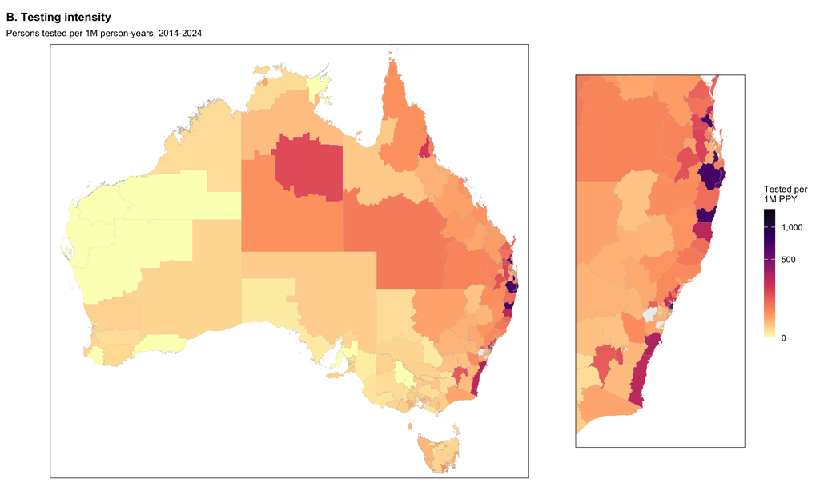

**Figure S7** Population-standardised and testing-standardised burden of α-Gal sensitisation, Australian SA3 regions, 2014–2024. Each panel shows all of mainland Australia (left) and zoomed in south-east Queensland and eastern New South Wales (right). **(A)** Sensitised individuals per million person-years, the population-standardised rate reported in the main text. **(B)** Persons tested per million person-years, showing testing intensity. **(C)** Test positivity (empirical Bayes smoothed) for regions with at least 20 persons tested, in which testing volume is the denominator; national positivity is 35.6% and regions with insufficient testing are shown in grey. Colour scales in A and B are square-root transformed.

**C. Testing-standardised burden**

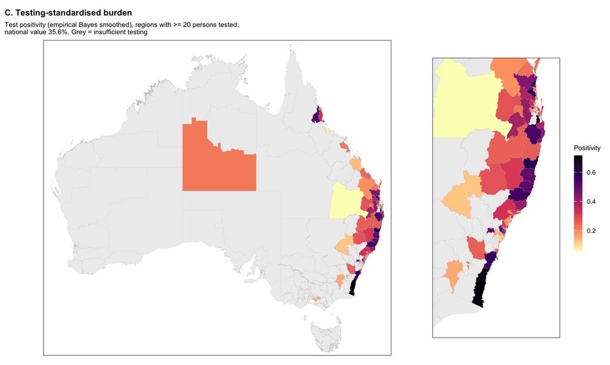

**Figure S7** Population-standardised and testing-standardised burden of α-Gal sensitisation, Australian SA3 regions, 2014–2024. Each panel shows all of mainland Australia (left) and zoomed in south-east Queensland and eastern New South Wales (right). **(A)** Sensitised individuals per million person-years, the population-standardised rate reported in the main text. **(B)** Persons tested per million person-years, showing testing intensity. **(C)** Test positivity (empirical Bayes smoothed) for regions with at least 20 persons tested, in which testing volume is the denominator; national positivity is 35.6% and regions with insufficient testing are shown in grey. Colour scales in A and B are square-root transformed.